# Лабораторная работа №2

Операционные системы

Кузьмина М. К.

Российский университет дружбы народов, Москва, Россия

2025

## Цель работы

Цель данной лабораторной работы – изучение идеологии и применения средств контроля версий, освоение умения по работе с git.

## Задание

1. Создать базовую конфигурацию для работы с git.
2. Создать ключ SSH.
3. Создать ключ PGP.
4. Создать локальный каталог для выполнения заданий по предмету.
5. Настроить каталог курса

## Создание базовой конфигурации для работы с git.

Устанавливаем git, gh, задаем имя и email владельца репозитория, настраиваем utf-8 в выводе сообщений git, задаем имя начальной ветки,:(рис.1):

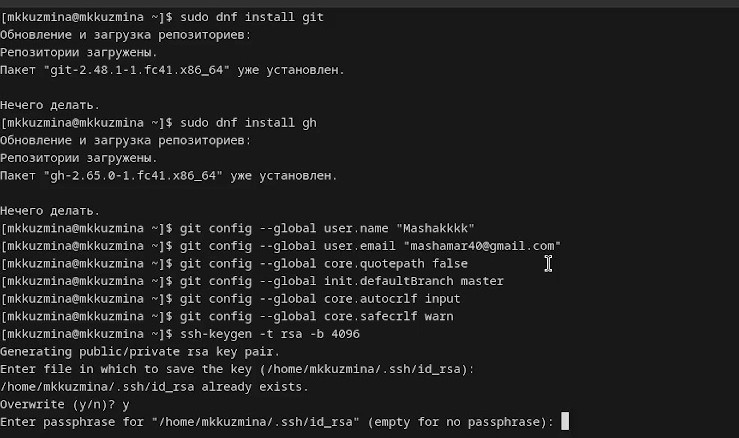

снимок экрана

## Создание ключа SSH.

Создаем ssh ключ (рис.2):

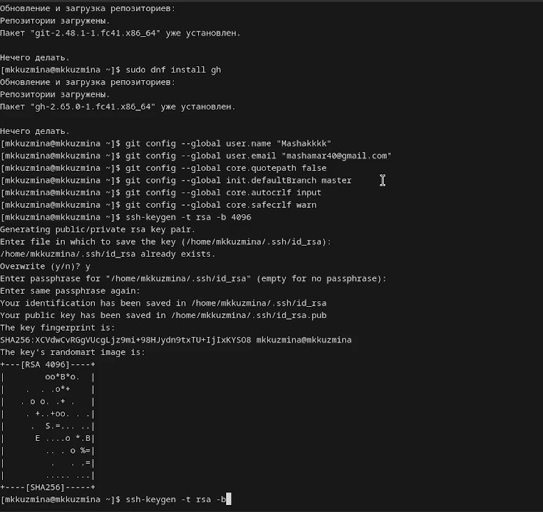

снимок экрана

## Создание ключа PGP

Создаем ключ и выбираем из предложенных опций тип, размер, срок действия (рис.3:

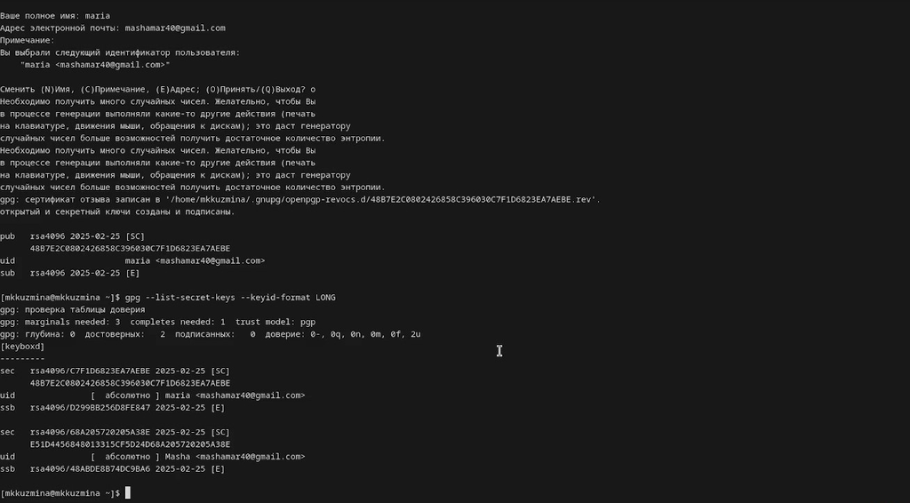

снимок экрана

Выводим список ключей и копируем отпечаток приватного ключа, копируем наш сгенерированный PGP ключ в буфер обмена, переходим на гитхаб и вставляем скопированный ключ, используя введёный email, указываем Git применять его при подписи коммитов (рис.4):

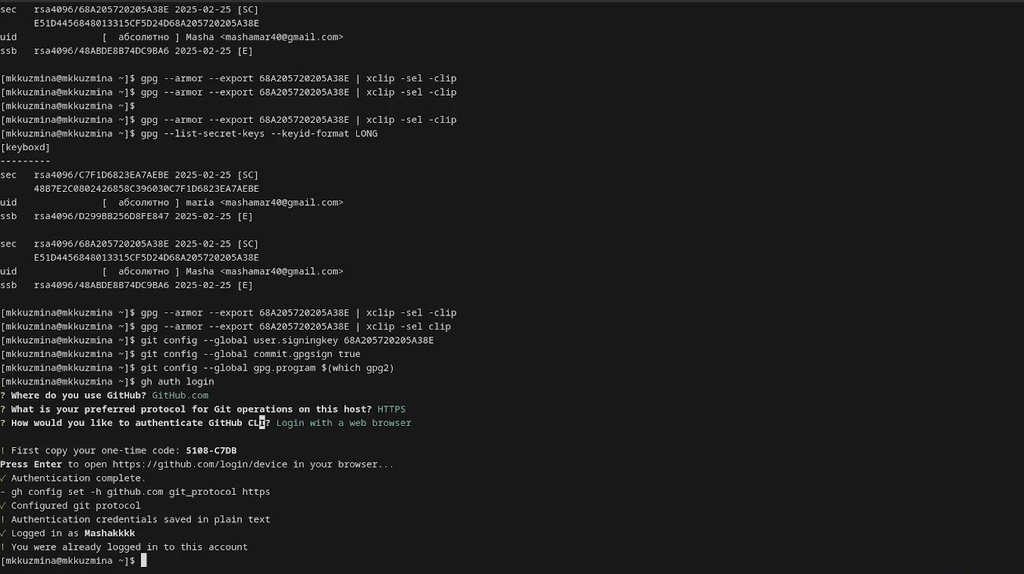

снимок экрана

## Создание локального каталога для выполнения заданий по предмету.

создаём директорию для работы, переходим в созданную директорию, создаём репозиторий на GitHub с указанным шаблоном и делает его публичным, клонируем созданный репозиторий в локальную папку os- с загрузкой всех подмодулей (–recursive).(рис.5):

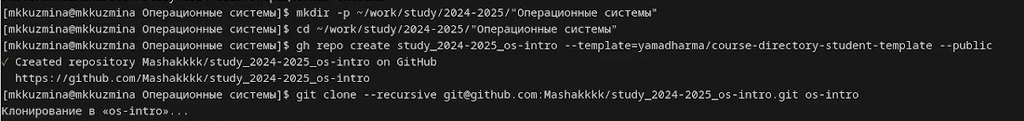

снимок экрана

## Настройка каталога курса

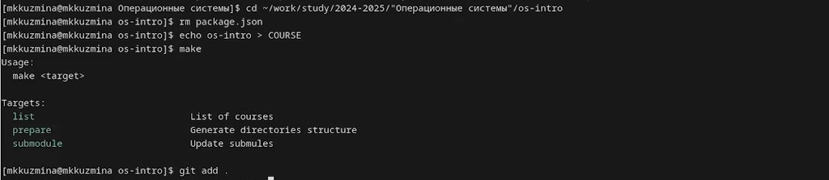

снимок экрана

отправляем на сервер (рис.7):

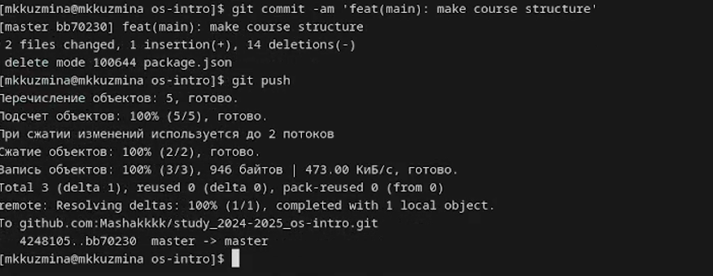

снимок экрана

## Выводы

При выполнении данной лабораторной работы была изучена идеология и применение средств контроля версий